# Modeling and prediction for movies

## Setup

### Load packages

```r
library(ggplot2)
library(dplyr)
library(statsr)
library(caret)
library(gridExtra)
library(plotly)
```

### Load data

```r
load("movies.Rdata")
```

## Part 1: Data

This data is collected from Rotten Tomatoes using random mehtods, so we can say that this data is generalizable to population. This data is also observational, so we can only get relations between variables.

## Part 2: Research question

We want to predict critics score on Rotten Tomatoes of movies. In general, we know that cristics look for innovation and messages among others. However, there are opinions who say that other factors influence on critics evaluations, for example, if the director ever won an Oscar (another movie), opinions tend to favour director’s movie.

##### Response variable:

- **critics_score (numerical)**: Critics score on Rotten Tomatoes.

##### Explanatory variable:

- **runtime (numerical)**: Runtime of movie (in minutes).
- **imdb_rating (numerical)**: Rating on IMDB.
- **imdb_num_votes (numerical)**: Number of votes on IMDB.
- **best_pic_nom (categorical)**: Whether or not the movie was nominated for a best picture Oscar (no, yes).
- **best_pic_win (categorical)**: Whether or not the movie won a best picture Oscar (no, yes).
- **best_dir_win (categorical)**: Whether or not the director of the movie ever won an Oscar (no, yes) – not that this is not necessarily whether the director won an Oscar for the given movie
- **audience_score (numerical)**: Audience score on Rotten Tomatoes.

## Part 3: Exploratory data analysis

#### Show distribution of response variable:

In the summary and boxplot, reponse variable (critics_score) looks having a nearly normal distribution; however in density plot, the explanatory variable behavior is more irregular. In response variable, this behavior is not a problem, the most important thing is not to have missing values.

```r
summary(movies$critics_score)
```

```
##    Min. 1st Qu.  Median    Mean 3rd Qu.    Max.
##    1.00   33.00   61.00   57.69   83.00  100.00
```

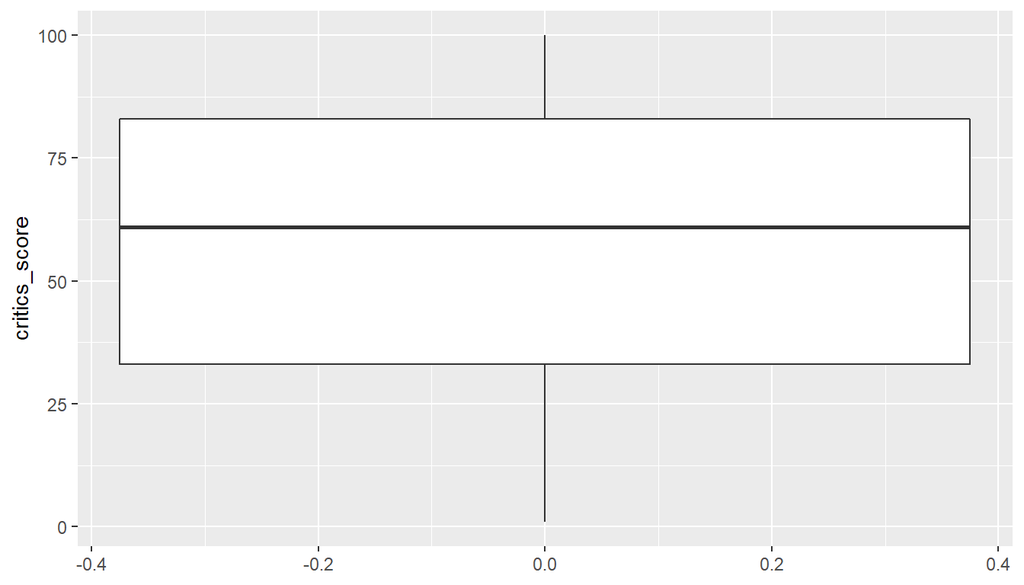

```r
ggplot(data = movies, aes(y = critics_score)) +
  geom_boxplot()
```

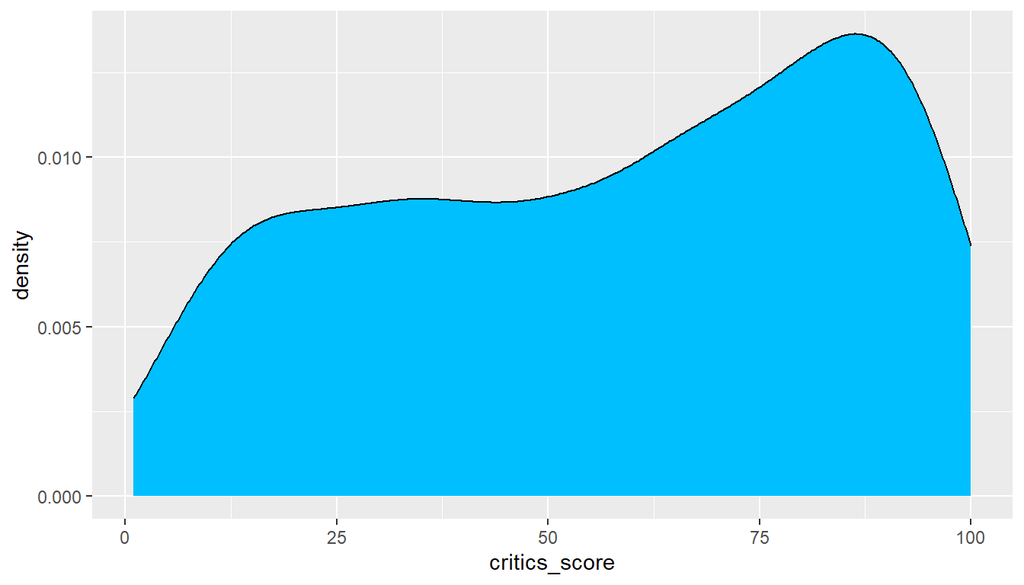

```r
ggplot(data = movies, aes(x = critics_score)) +
  geom_density(fill = 'deepskyblue')
```

There is no missing values, so our response variable is OK.

```r
sum(is.na(movies$critics_score))
```

```
## [1] 0
```

#### Show distribution of explanatory variables:

##### Showing numerical variables:

In the summary table, we focus on missing values and outliers, because theses cases have a huge impact in our model. There is only one missing value (runtime variable) where its impact is affordable, so we will remove it from our sample. Another important issue is to identify numerical variables that have outliers. Showing this summary, we can say that runtime and imdb_num_votes variables have outliers, because their maximum value it far way from mean.

```r
movies %>%
  select(runtime, imdb_rating, imdb_num_votes, best_pic_nom, best_pic_win, best_dir_win, audience_score) %>%
  summary()
```

```
##     runtime       imdb_rating    imdb_num_votes   best_pic_nom
##  Min.   : 39.0   Min.   :1.900   Min.   :   180   no :629
##  1st Qu.: 92.0   1st Qu.:5.900   1st Qu.:  4546   yes: 22
##  Median :103.0   Median :6.600   Median : 15116
##  Mean   :105.8   Mean   :6.493   Mean   : 57533
##  3rd Qu.:115.8   3rd Qu.:7.300   3rd Qu.: 58301
##  Max.   :267.0   Max.   :9.000   Max.   :893008
##  NA's   :1
##  best_pic_win best_dir_win audience_score
##  no :644      no :608      Min.   :11.00
##  yes:  7      yes: 43      1st Qu.:46.00
##                            Median :65.00
##                            Mean   :62.36
##                            3rd Qu.:80.00
##                            Max.   :97.00
##
```

```r
plot1 <- ggplot(data = movies, aes(x = runtime)) +
  geom_histogram()
plot2 <- ggplot(data = movies, aes(x = imdb_num_votes)) +
  geom_histogram()
plot3 <- ggplot(data = movies, aes(x = imdb_rating)) +
  geom_histogram()
plot4 <- ggplot(data = movies, aes(x = audience_score)) +
  geom_histogram()
```

- **runtime** variable has some outliers, but its distribution is nearly normal.
- **imdb_num_votes** variable has many outliers and its distribution is rigth skewed.
- **imdb_rating** variable has a nearly normal distribution.
- **audience_score** variable has an irregular distribution. We can say that is nearly left skewed.

In conlusion, we should be worry for imdb_num_votes, because this variable will not meet regression requirements. However, I will use this variable for experiment reasons.

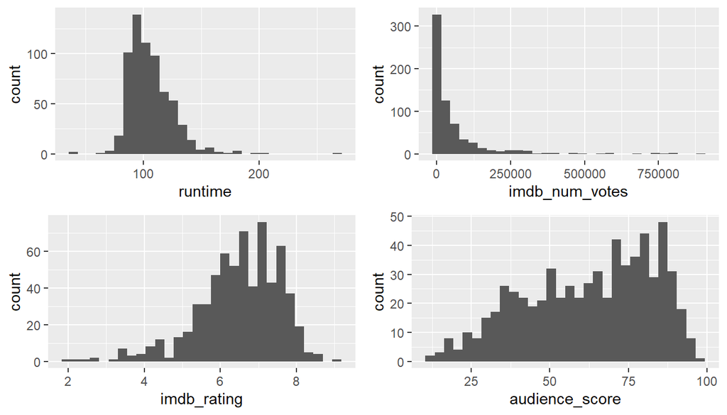

```r
grid.arrange(plot1, plot2, plot3, plot4, ncol = 2, nrow = 2)
```

##### Showing categorical variables:

```r
plot5 <- ggplot(data = movies, aes(x = factor(best_dir_win), y = critics_score)) +
  geom_boxplot()
plot6 <- ggplot(data = movies, aes(x = factor(best_pic_win), y = critics_score)) +
  geom_boxplot()
```

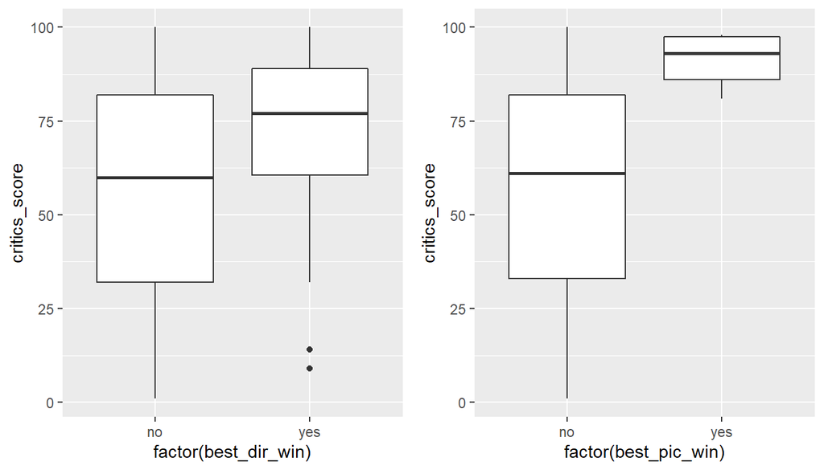

```r
grid.arrange(plot5, plot6, ncol = 2)
```

## Part 4: Modeling

#### Cleaning data

Remove missing values.

```r
movies_clean <- select(movies, critics_score, runtime, imdb_rating, imdb_num_votes, best_pic_nom, best_pic_win, best_dir_win, audience_score)
movies_clean <- filter(movies_clean, !is.na(runtime))
```

#### Preprocessing data.

We standarize numerical variables, in order to improve results of the model.

```r
preprocessvalues <- movies_clean %>%
  select(runtime, imdb_rating, imdb_num_votes, audience_score) %>%
    preProcess(method = c('scale', 'center'))

transformedvalues <- predict(preprocessvalues, movies_clean)
summary(transformedvalues)
```

```
##  critics_score       runtime         imdb_rating       imdb_num_votes
##  Min.   :  1.00   Min.   :-3.4364   Min.   :-4.23237   Min.   :-0.5120
##  1st Qu.: 33.00   1st Qu.:-0.7108   1st Qu.:-0.54527   1st Qu.:-0.4727
##  Median : 61.00   Median :-0.1451   Median : 0.09998   Median :-0.3781
##  Mean   : 57.65   Mean   : 0.0000   Mean   : 0.00000   Mean   : 0.0000
##  3rd Qu.: 83.00   3rd Qu.: 0.5106   3rd Qu.: 0.74522   3rd Qu.: 0.0077
##  Max.   :100.00   Max.   : 8.2889   Max.   : 2.31224   Max.   : 7.4463
##  best_pic_nom best_pic_win best_dir_win audience_score
##  no :628      no :643      no :607      Min.   :-2.5376
##  yes: 22      yes:  7      yes: 43      1st Qu.:-0.8079
##                                         Median : 0.1311
##                                         Mean   : 0.0000
##                                         3rd Qu.: 0.8724
##                                         Max.   : 1.7125
```

#### Diagnostics

We check if conditions for regression modeling are satisfied. This condition is fairly satisfied for response variable, because its distribution is nearly normal.

```r
lm_full <- lm(critics_score ~ runtime + imdb_rating + imdb_num_votes + best_pic_nom + best_pic_win + best_dir_win + audience_score, data = transformedvalues)
```

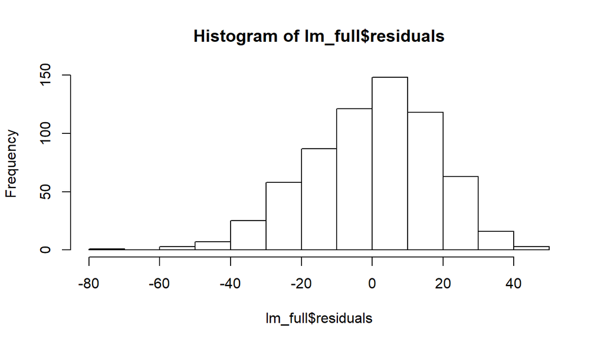

```r
hist(lm_full$residuals)
```

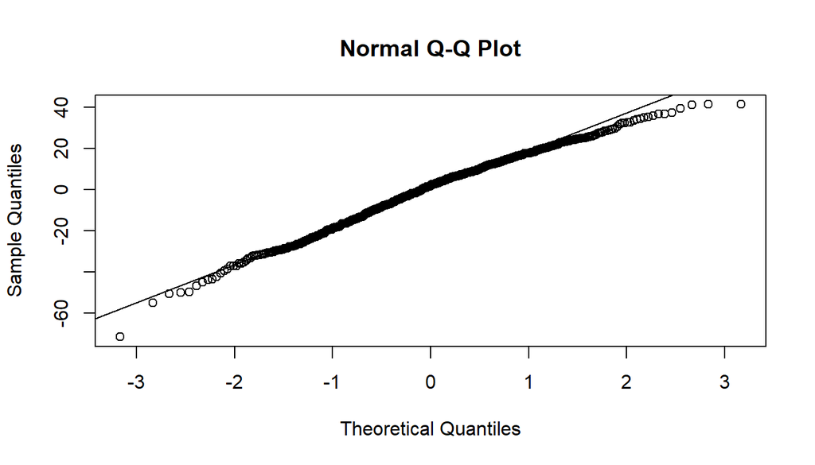

```r
qqnorm(lm_full$residuals)
qqline(lm_full$residuals)
```

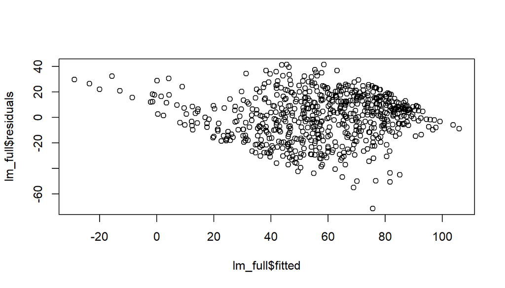

```r
plot(lm_full$residuals ~ lm_full$fitted)
```

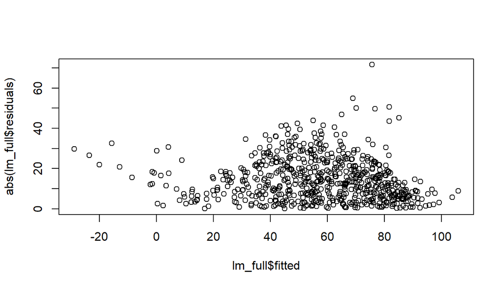

```r
plot(abs(lm_full$residuals) ~ lm_full$fitted)
```

We check conditions for explanatory variables (Fitted: predicted values (y-hat)).

We see that this condition is not satisfied, because the variability is not constant. Some regions have few observation and others have mnay.

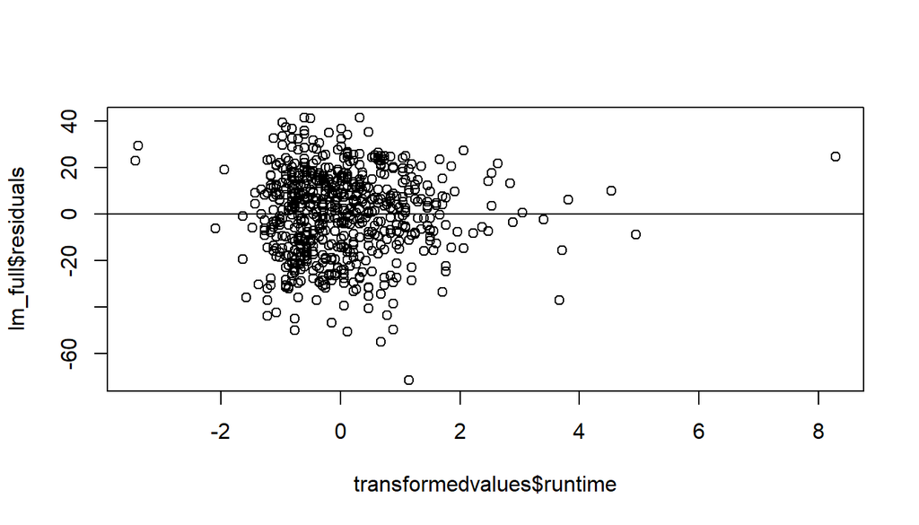

```r
plot(lm_full$residuals ~ transformedvalues$runtime)
abline(0, 0)
```

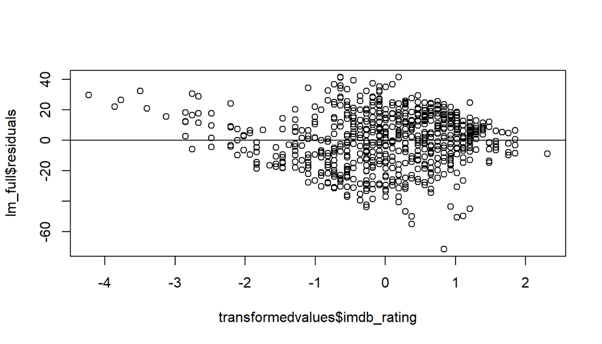

```r
plot(lm_full$residuals ~ transformedvalues$imdb_rating)
abline(0, 0)
```

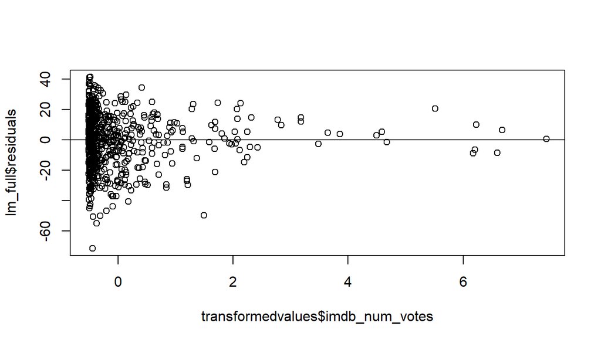

```r
plot(lm_full$residuals ~ transformedvalues$imdb_num_votes)
abline(0, 0)
```

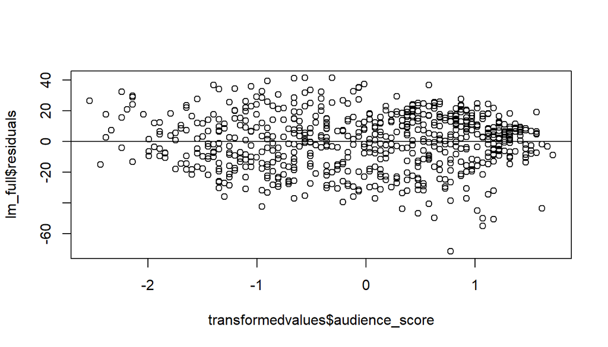

```r
plot(lm_full$residuals ~ transformedvalues$audience_score)
abline(0, 0)
```

#### Solution

To solve these problems, we will limit the number of observations to regions where there many observations, because its variability is constant. This region goes from -1.5 to 1.5.

```r
transformedvalues <- transformedvalues %>%
  filter(runtime >= -1.5, runtime <= 1.5, imdb_rating >= -1.5, imdb_rating <= 1.5, imdb_num_votes >= -1.5, imdb_num_votes <= 1.5, audience_score >= -1.5, audience_score <= 1.5)

lm_full <- lm(critics_score ~ runtime + imdb_rating + imdb_num_votes + best_pic_nom + best_pic_win + best_dir_win + audience_score, data = transformedvalues)
```

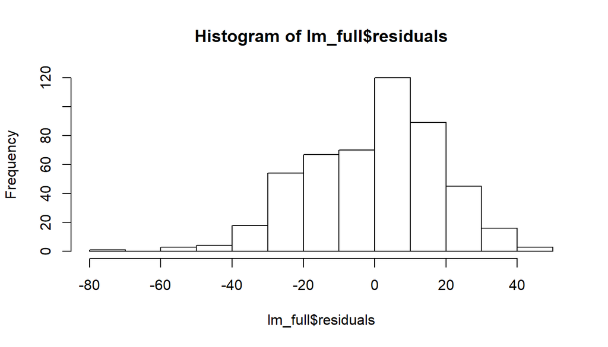

```r
hist(lm_full$residuals)
```

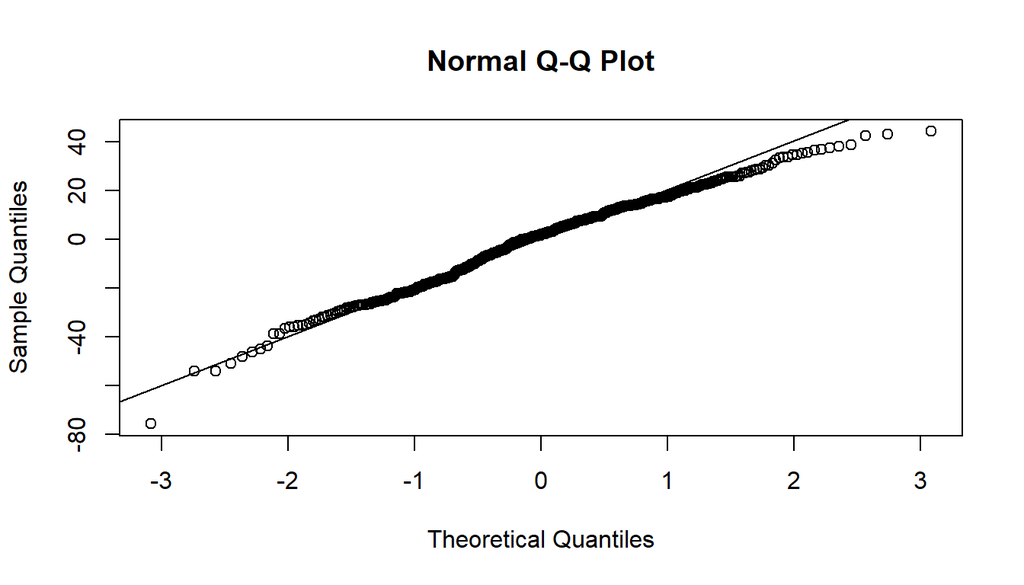

```r
qqnorm(lm_full$residuals)
qqline(lm_full$residuals)
```

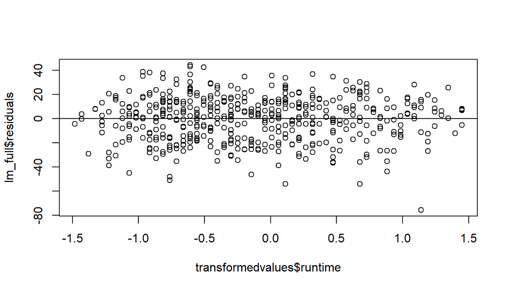

```r
plot(lm_full$residuals ~ transformedvalues$runtime)
abline(0, 0)
```

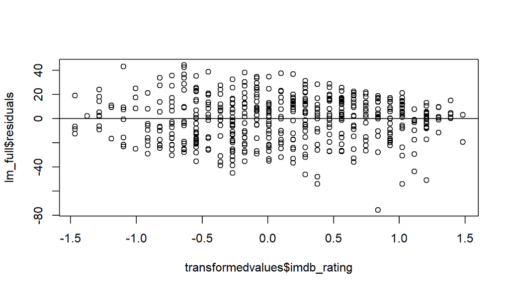

```r
plot(lm_full$residuals ~ transformedvalues$imdb_rating)
abline(0, 0)
```

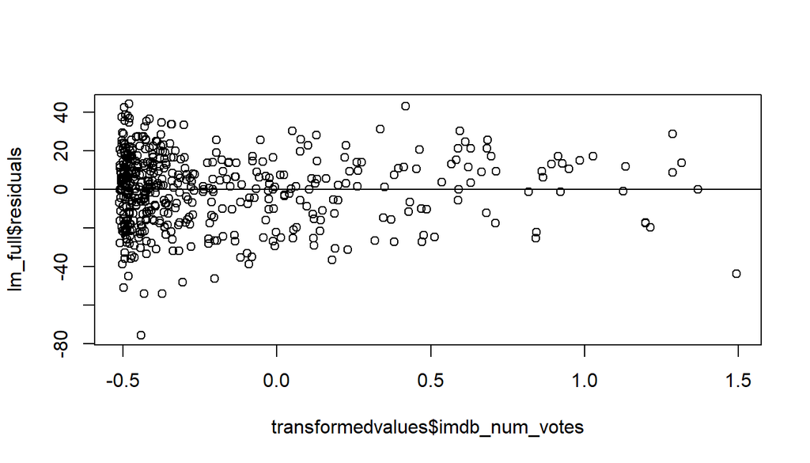

```r
plot(lm_full$residuals ~ transformedvalues$imdb_num_votes)
abline(0, 0)
```

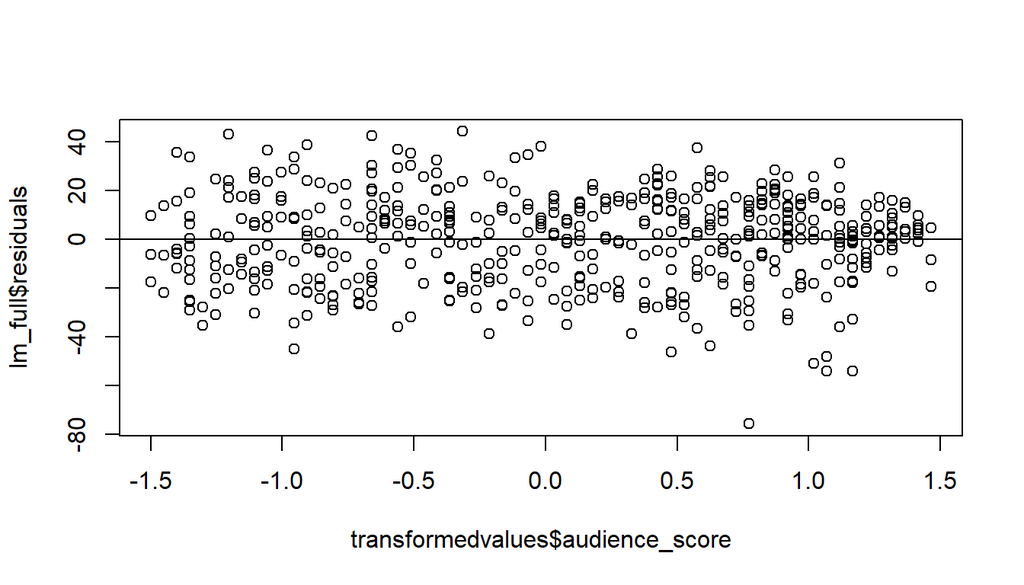

```r
plot(lm_full$residuals ~ transformedvalues$audience_score)
abline(0, 0)
```

#### Model selection

We will use backwads elimination by adjusted R-square.

```r
summary(lm_full)
```

```
##
## Call:
## lm(formula = critics_score ~ runtime + imdb_rating + imdb_num_votes +
##     best_pic_nom + best_pic_win + best_dir_win + audience_score,
##     data = transformedvalues)
##
## Residuals:
##    Min     1Q Median     3Q    Max
## -75.65 -13.23   1.98  13.85  44.31
##
## Coefficients:
##                 Estimate Std. Error t value Pr(>|t|)
## (Intercept)      54.8137     1.0056  54.508  < 2e-16 ***
## runtime          -0.5746     1.2783  -0.449 0.653281
## imdb_rating      25.3610     2.4904  10.184  < 2e-16 ***
## imdb_num_votes   -8.2033     2.1412  -3.831 0.000144 ***
## best_pic_nomyes  14.9587     7.7901   1.920 0.055422 .
## best_pic_winyes -10.1010    20.2904  -0.498 0.618838
## best_dir_winyes   6.5066     4.0606   1.602 0.109728
## audience_score    0.8099     2.0288   0.399 0.689904
## ---
## Signif. codes:  0 '***' 0.001 '**' 0.01 '*' 0.05 '.' 0.1 ' ' 1
##
## Residual standard error: 18.77 on 482 degrees of freedom
## Multiple R-squared:  0.4861, Adjusted R-squared:  0.4787
## F-statistic: 65.15 on 7 and 482 DF,  p-value: < 2.2e-16
```

```r
lm1 <- lm(critics_score ~ imdb_rating + imdb_num_votes + best_pic_nom + best_pic_win + best_dir_win + audience_score, data = transformedvalues)
summary(lm1)$adj.r.squared
```

```
## [1] 0.4795486
```

```r
lm2 <- lm(critics_score ~ runtime + imdb_num_votes + best_pic_nom + best_pic_win + best_dir_win + audience_score, data = transformedvalues)
summary(lm2)$adj.r.squared
```

```
## [1] 0.3678349
```

```r
lm3 <- lm(critics_score ~ runtime + imdb_rating + best_pic_nom + best_pic_win + best_dir_win + audience_score, data = transformedvalues)
summary(lm3)$adj.r.squared
```

```
## [1] 0.4639237
```

```r
lm4 <- lm(critics_score ~ runtime + imdb_rating + imdb_num_votes + best_pic_win + best_dir_win + audience_score, data = transformedvalues)
summary(lm4)$adj.r.squared
```

```
## [1] 0.475787
```

```r
lm5 <- lm(critics_score ~ runtime + imdb_rating + imdb_num_votes + best_pic_nom + best_dir_win + audience_score, data = transformedvalues)
summary(lm5)$adj.r.squared
```

```
## [1] 0.4794992
```

```r
lm6 <- lm(critics_score ~ runtime + imdb_rating + imdb_num_votes + best_pic_nom + best_pic_win + audience_score, data = transformedvalues)
summary(lm6)$adj.r.squared
```

```
## [1] 0.4769954
```

```r
lm7 <- lm(critics_score ~ runtime + imdb_rating + imdb_num_votes + best_pic_nom + best_pic_win + best_dir_win, data = transformedvalues)
summary(lm7)$adj.r.squared
```

```
## [1] 0.4795946
```

The best adjusted R-square is **0.4796**.

```r
summary(lm7)
```

```
##
## Call:
## lm(formula = critics_score ~ runtime + imdb_rating + imdb_num_votes +
##     best_pic_nom + best_pic_win + best_dir_win, data = transformedvalues)
##
## Residuals:
##     Min      1Q  Median      3Q     Max
## -75.624 -13.664   1.975  13.784  44.611
##
## Coefficients:
##                 Estimate Std. Error t value Pr(>|t|)
## (Intercept)      54.7772     1.0006  54.744  < 2e-16 ***
## runtime          -0.6354     1.2681  -0.501 0.616543
## imdb_rating      26.2165     1.2678  20.679  < 2e-16 ***
## imdb_num_votes   -8.1845     2.1388  -3.827 0.000147 ***
## best_pic_nomyes  15.0411     7.7806   1.933 0.053801 .
## best_pic_winyes -10.1401    20.2725  -0.500 0.617168
## best_dir_winyes   6.4504     4.0546   1.591 0.112295
## ---
## Signif. codes:  0 '***' 0.001 '**' 0.01 '*' 0.05 '.' 0.1 ' ' 1
##
## Residual standard error: 18.75 on 483 degrees of freedom
## Multiple R-squared:  0.486,  Adjusted R-squared:  0.4796
## F-statistic: 76.11 on 6 and 483 DF,  p-value: < 2.2e-16
```

## Part 5: Prediction

```r
# Showing top data
head(movies_clean)
```

```
## # A tibble: 6 x 8
##   critics_score runtime imdb_rating imdb_num_votes best_pic_nom
##           <dbl>   <dbl>       <dbl>          <int> <fct>
## 1            45      80         5.5            899 no
## 2            96     101         7.3          12285 no
## 3            91      84         7.6          22381 no
## 4            80     139         7.2          35096 no
## 5            33      90         5.1           2386 no
## 6            91      78         7.8            333 no
## # ... with 3 more variables: best_pic_win <fct>, best_dir_win <fct>,
## #   audience_score <dbl>
```

```r
# Setting variables
runtime <- 80
rating <- 5.5
votes <- 899
best_pic_nom <- 0
best_pic_win <- 0
best_dir_win <- 0

# Standarize observactions
predictdata = data.frame(runtime = c(runtime), imdb_rating = c(rating), imdb_num_votes = c(votes), audience_score = c(1000))
transformedvalues2 <- predict(preprocessvalues, predictdata)

# Predict score
54.7772 - 0.6354*transformedvalues2$runtime + 26.2165*transformedvalues2$imdb_rating - 8.1845*transformedvalues2$imdb_num_votes + 15.0411*best_pic_nom - 10.1401*best_pic_win + 6.4504*best_dir_win
```

```
## [1] 35.79767
```

## Part 6: Conclusion

Linear regression is easy and powerful, for that reason this method is one of the most popular to make predictions. However, we need to prepare the data to get good predictions. Working with this data, the most difficult shortcoming was its variability, because some variables were to skewed, and that makes difficult to get good predictions.

For me, the most difficult variables are the caregorical. In this case, I will have to use ont-hot encoding.